# Visualizing your data with `ggplot`

## Saving plots

When working with `ggplot`, save figures using the `ggsave()` function. Note that to use this function, you’ll need to dump your ggplot into a variable:

```r
my_sweet_plot <- ggplot(data = my_data) +
  geom_point(aes(x = YEAR, y = VALUE))

ggsave(my_sweet_plot, "./myfigure.png")
```

You can read more about writing your figures to a other types of files [here](http://stat545.com/block017_write-figure-to-file.html).

# Critical Reflection Questions

1. What makes a visualization a good visualization? Work together to come up with a set of criteria for our visualizations. To do this, each of you will go out and search the InterWebs for a data visualization you find particularly awful or particularly epic. Then do the following:
- Share the visualization with classmates and list the factors that make this visualization epic or awful.
- React to another classmate’s visualization and add factors that you think make this visualization epic or awful.
- Then, we’ll discuss your examples in class as we work towards a set of “visualization best practice” rules.

# DIY Questions

Get as close as you can to re-creating this visualization from the `gapminder` dataset in the `dslabs` package:

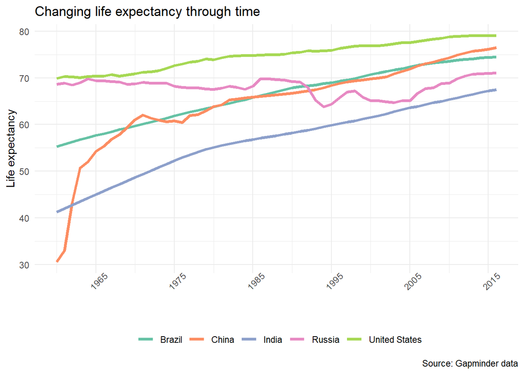

# Additional Resources

- The [ggplot2 cheatsheet](https://www.rstudio.com/wp-content/uploads/2015/03/ggplot2-cheatsheet.pdf)
- Read the R for Data Science chapter on [Data Visualization](https://r4ds.had.co.nz/data-visualisation.html).
- Pretty much [this whole book!](https://serialmentor.com/dataviz/) Helpful reference, not at all required reading.
- [Be awesome in ggplot](http://www.sthda.com/english/wiki/be-awesome-in-ggplot2-a-practical-guide-to-be-highly-effective-r-software-and-data-visualization)
- Kieran Healy’s [online textbook](https://socviz.co/) on data visualization in R.